# HR - 2D - Analysis

## Authors

- Carlos Ramos Mateos
- Miguel Ángel Mancheño Yustres
- Pablo Aguilera Onieva
- Javier Irigoyen Muñoz
- Javier Jiménez Rodríguez

## Reasoning

Here we are going to study the following HR-2D system: $$ \begin{gather*} \dot x = y - Ax^3 + Bx^2 + I - z \\ \dot y = C - Dx^2 - y \\ \\ \end{gather*} $$

$$ \begin{gather*} \text{The $\textbf{default}$ constant values will be:} \\ \end{gather*} $$$$ \begin{gather*} A = 1, & B = 2.6, & C = 1 \\ D = 5, & I(\infty) = 2, & I_0 = 1 \\ &z = 0& \end{gather*} $$

> **Note**

> Our notation for stable, unstable, ..., points will be:
> - CRIT_POINT_STABLE_MARKER = 'o' -> Stable nodes.
> - CRIT_POINT_SADDLE_MARKER = '$\diamondsuit$' -> Saddle-Points.
> - CRIT_POINT_UNSTABLE_SPIRAL_MARKER = '$\circlearrowright$' -> Unstable Focus.
> - CRIT_POINT_NON_ISOLATED_MARKER = '+' -> Non-isolated equilibrium.

## Workspace

```python
from scipy.integrate import odeint
import numpy as np
from numpy.linalg import eig
import matplotlib.pyplot as plt
from collections import deque
from lib.Utils import print_equations
from lib.hr_2d import (hr_dt, dx_nul, dy_nul)
from lib.plot_utils import (plot_critical_points,
                            add_plot_properties,
                            plot_phase_space,
                            plot_bifurcation_diagram)
from lib.dyn_sys_utils import (prepare_phase_space_values,
                               prepare_phase_space_values_around_point,
                               obtain_critical_points,
                               prepare_bifurcation_plot)

# system parameters
from lib.hr_2d import (A, B, C, D, I_0, I_INF, Z,
                       STABLE_STATE, SILENT_STATE,
                       T_START, T_END, T_STEP)

# system evolution macros
from lib.plot_utils import (TIME_TITLE, TIME_OX_LABEL,
                            TIME_OY_LABEL)
# phase space macros
from lib.plot_utils import (OX_LABEL, OY_LABEL, TITLE,
                            X_NUL_TITLE, Y_NUL_TITLE,
                            X_NUL_COLOR, Y_NUL_COLOR,
                            X_NUL_LABEL, Y_NUL_LABEL,
                            CRIT_POINT_LABEL, CRIT_POINT_COLOR,
                            CRIT_POINT_STABLE_MARKER,
                            CRIT_POINT_SADDLE_MARKER,
                            CRIT_POINT_UNSTABLE_SPIRAL_MARKER,
                            CRIT_POINT_NON_ISOLATED_MARKER,
                            ARROWS_LABEL, ARROWS_COLOR)

%load_ext autoreload
%autoreload 2
```

## HR-2D system & pulse dynamic ($I$)

### Common parameters

The parameters used in this section are not the same as the mentioned in the introduction and in the cells below the Critical points - Section. We did this to synchronize the results with the `HR_3D.ipynb` notebook.

We decided to do this in order to obtain better parameters that explains easier the 2D bifurcation plot.

So, the parameters used in this section will be the following: $$ \begin{gather*} A = 1, & B = 3, & C = 1 \\ D = 5, & I(\infty) = 0, & I_0 = 1 \end{gather*} $$

$$ \begin{gather*} \text{Where $I$ will follow the next dynamic:} \\ I = \begin{cases} I(\infty), & \text{if there is not a pulse} \\ I_0, & \text{otherwise} \end{cases} \\ \end{gather*} $$

> **Pulse's dynamic**

> A pulse will occur if we are in a specific time interval $[t_0, t_f]$ and it will be a square pulse of $t_f - t_0 = 1ms$ **by default**.

To avoid long stabilization times of our system we will assign the following **initial values by default**: $$ \begin{gather*} x_0 = -0.8610800560651974, & y_0 = -2.7984503338411115 \end{gather*} $$

```python
# parameters
a = 1
b = 3
c = 1
d = 5

## pulses
pulse_times = deque()
i_0 = 1
i_inf = 0
z = 0

# args
args = (a, b, c, d, pulse_times, i_0, i_inf, z)

# values of time
t = np.arange(T_START, T_END, T_STEP)
```

#### Normal behaviour

With common values as:

```
STABLE_STATE = \
    (-0.8610800560651974, -2.7984503338411115)
```

We can achieve a regular activity.

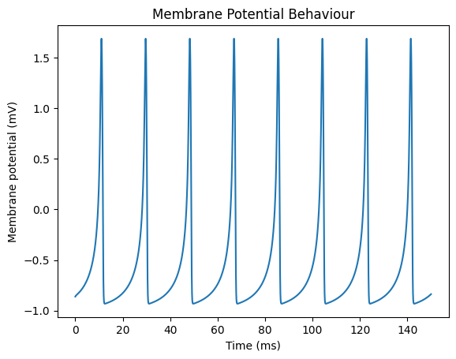

```python
# initial state
state = STABLE_STATE

# solving ODE
state = odeint(hr_dt, state, t, args=args)

# plot results
plt.plot(t, state[:, 0])
plt = add_plot_properties(plt, x_label=TIME_OX_LABEL,
                          y_label=TIME_OY_LABEL,
                          title=TIME_TITLE)
plt.show()
```

#### Silent behaviour

With a Membrane Potential at hyperpolarization values as:

```
SILENT_STATE = (0.6, 1)
```

We can achieve a silent behaviour of the neuron.

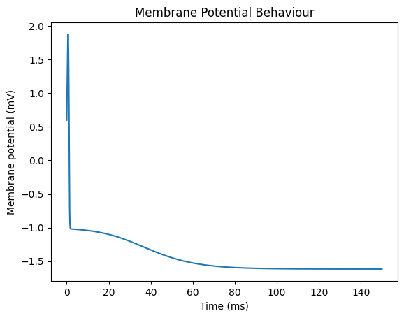

```python
# initial state
state = SILENT_STATE

# solving ODE
state = odeint(hr_dt, state, t, args=args)

# plot results
plt.plot(t, state[:, 0])
plt = add_plot_properties(plt, x_label=TIME_OX_LABEL,
                          y_label=TIME_OY_LABEL,
                          title=TIME_TITLE)
plt.show()
```

#### Transition from Silent to Normal behaviour

From the previous silent state, giving a pulse of ~10-100ms we can achieve the following transition.

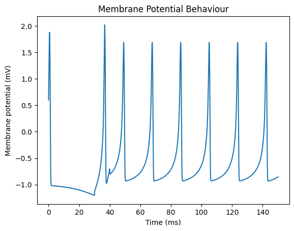

```python
# pulses
pulse_times = deque()
pulse_times.append((30, 40))

# args
args = (a, b, c, d, pulse_times, i_0, i_inf, z)

# initial state
state = SILENT_STATE

# solving ODE
state = odeint(hr_dt, state, t, args=args)

# plot results
plt.plot(t, state[:, 0])
plt = add_plot_properties(plt, x_label=TIME_OX_LABEL,
                          y_label=TIME_OY_LABEL,
                          title=TIME_TITLE)
plt.show()
```

#### Transition from Normal to Silent behaviour

Starting from the normal behaviour we can switch into a silent behaviour by adding a pulse in the peak of a spike for ~1-5ms.

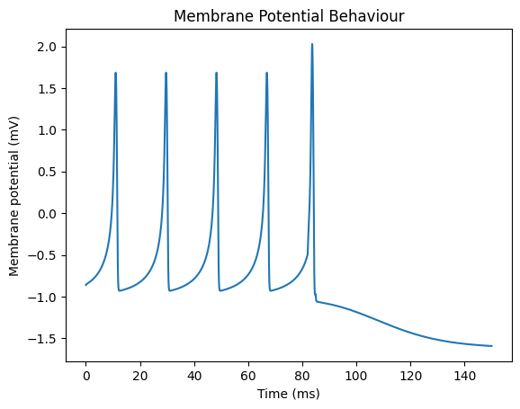

```python
pulse_times = deque()
pulse_times.append((82, 85))

# args
args = (a, b, c, d, pulse_times, i_0, i_inf, z)

# initial state
state = STABLE_STATE

# solving ODE
state = odeint(hr_dt, state, t, args=args)

# plot results
plt.plot(t, state[:, 0])
plt = add_plot_properties(plt, x_label=TIME_OX_LABEL,
                          y_label=TIME_OY_LABEL,
                          title=TIME_TITLE)
plt.show()
```

#### Transition from Normal to Silent behaviour and viceversa

Here we are going to apply the previous two replicated dinamycs.

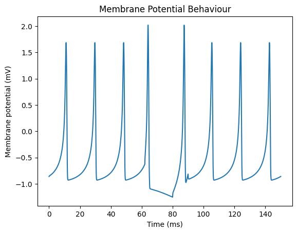

```python
pulse_times = deque()
pulse_times.append((62, 65))
pulse_times.append((80, 90))

# args
args = (a, b, c, d, pulse_times, i_0, i_inf, z)

# initial state
state = STABLE_STATE

# solving ODE
state = odeint(hr_dt, state, t, args=args)

# plot results
plt.plot(t, state[:, 0])
plt = add_plot_properties(plt, x_label=TIME_OX_LABEL,
                          y_label=TIME_OY_LABEL,
                          title=TIME_TITLE)
plt.show()
```

## Critical points

Original ODE: $$ \begin{gather*} \dot x = y - Ax^3 + Bx^2 + I - z \\ \dot y = C - Dx^2 - y \\ \end{gather*} $$

We will obtain the critical points where the following equations are satisfied: $$ \begin{gather*} \dot x &=& 0 \\ \dot y &=& 0 \end{gather*} $$

Remember that, from now on, the parameters will be the following: $$ \begin{gather*} A = 1, & B = 2.6, & C = 1 \\ D = 5, & I(\infty) = 2, & I_0 = 1 \\ &z = 0& \end{gather*} $$

```python
# common values
a = A
b = B
c = C
d = D
i_inf = I_INF
i_0 = I_0
pulse_times = deque()
z = Z

# args
args = (a, b, c, d, pulse_times, i_0, i_inf, z)

# we will leave all the system in function of "x"
x_start, x_stop = (-2, 2)
y_start, y_stop = (-15, 5)

values = 1000
x = np.linspace(x_start, x_stop, values)

# plot utilities
x_lim = (x_start, x_stop)
y_lim = (y_start, y_stop)

# quiver utilities
n_arrows = 12j

# nulclines
## dx
dx_nul_params = {
    'a': A,
    'x': x,
    'b': B,
    'i': i_inf,
    'z': z
}

dx_nul_vals = dx_nul(**dx_nul_params)

## dy
dy_nul_params = {
    'c': C,
    'd': D,
    'x': x,
}

dy_nul_vals = dy_nul(**dy_nul_params)

# default params
default_params =\
    {
        't': 0,
        'a': A,
        'b': B,
        'c': C,
        'd': D,
        'pulse_times': deque(),
        'i': I_INF,
        'i_0': I_0,
        'i_inf': I_INF,
        'z': Z,
        'dx_nul': dx_nul,
        'dy_nul': dy_nul,
        'dyn_sys': hr_dt
    }
```

### OX - Nulcline

If we have $\dot x = 0$, then: $$ \begin{gather*} y - Ax^3 + Bx^2 + I - z &=& 0 \\ y &=& Ax^3 - Bx^2 - I + z \end{gather*} $$

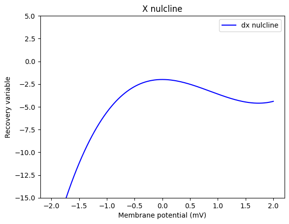

```python
plt.plot(x, dx_nul_vals, color=X_NUL_COLOR,
         label=X_NUL_LABEL)
plt = add_plot_properties(plt, x_label=OX_LABEL,
                          y_label=OY_LABEL,
                          title=X_NUL_TITLE,
                          y_lim=y_lim)
plt.legend()
```

### OY - Nulcline

If we have $\dot y = 0$, then: $$ \begin{gather*} C - Dx^2 - y &=& 0 \\ y &=& C - Dx^2 \end{gather*} $$

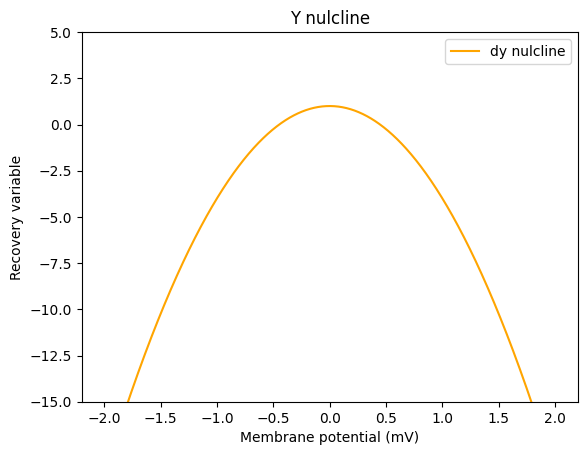

```python
plt.plot(x, dy_nul_vals, color=Y_NUL_COLOR,
         label=Y_NUL_LABEL)
plt = add_plot_properties(plt, x_label=OX_LABEL,
                          y_label=OY_LABEL,
                          title=Y_NUL_TITLE,
                          y_lim=y_lim)
plt.legend()
```

### Critical points solutions

As we mentioned they are obtained when: $$ \begin{gather*} \dot x &=& 0 \\ \dot y &=& 0 \end{gather*} $$

So, as we shown in the previous cells, we have:

$$ \begin{gather*} &\text{dx nulcline:}& \\ &\dot x = 0& \\ &y - Ax^3 + Bx^2 + I(\infty) - z = 0& \\ &y = Ax^3 - Bx^2 - I(\infty) + z& \\ \\ &\text{dy nulcline:}& \\ &\dot y = 0& \\ &C - Dx^2 - y = 0& \\ &y = C - Dx^2& \\ \\ &\text{In summary:}& \\ &y = Ax^3 - Bx^2 - I(\infty) + z& \\ &y = C - Dx^2& \\ \\ &\text{So:}& \\ &Ax^3 - Bx^2 - I(\infty) + z = C - Dx^2& \\ &Ax^3 - Bx^2 + Dx^2 = C + I(\infty) - z& \\ &x^2(Ax - B + D) = C + I(\infty) - z& \\ \end{gather*} $$$$ \begin{gather*} &\text{Having:}& \\ A = 1, & B = 2.6, & C = 1 \\ D = 5, & I(\infty) = 2, & I_0 = 1 \\ &z = 0& \end{gather*} $$$$ \begin{gather*} &x^2(x - 2.6 + 5) = 1 + 2 - 0& \\ &x^2(x + 2.4) = 3& \\ \end{gather*} $$

> **Note**

> Our notation for stable, unstable, ..., points will be:
> - CRIT_POINT_STABLE_MARKER = 'o' -> Stable nodes.
> - CRIT_POINT_SADDLE_MARKER = '$\diamondsuit$' -> Saddle-Points.
> - CRIT_POINT_UNSTABLE_SPIRAL_MARKER = '$\circlearrowright$' -> Unstable Focus.
> - CRIT_POINT_NON_ISOLATED_MARKER = '+' -> Non-isolated equilibrium.

```python
y_1 = lambda x: default_params['a']*x*x*x -\
    default_params['b']*x*x - default_params['i_inf'] + default_params['z']
y_2 = lambda x: default_params['c'] - default_params['d']*x*x

equations = [y_1, y_2]
coefs = [1, 2.4, 0, -3]

x_sols, equations_sols =\
    obtain_critical_points(coefs, equations)

print_equations(default_params['i_inf'], default_params['z'], x_sols, equations_sols)

y_sols = equations_sols[0]

# Critical points
c_1 = (x_sols[0], y_sols[0])
```

```
First equation: y_1 = lambda x: x*x*x - 2.6*x*x - 2
	Solutions:
	 x: [0.94677612+0.j]
	 y: [-3.48192513]

Second equation: y_2 = lambda x: 1 - 5*x*x
	Solutions:
	 x: [0.94677612+0.j]
	 y: [-3.48192513]

They are both the same!
```

### Critical Points Plot

> **Note**

> Our notation for stable, unstable, ..., points will be:
> - CRIT_POINT_STABLE_MARKER = 'o' -> Stable nodes.
> - CRIT_POINT_SADDLE_MARKER = '$\diamondsuit$' -> Saddle-Points.
> - CRIT_POINT_UNSTABLE_SPIRAL_MARKER = '$\circlearrowright$' -> Unstable Focus.
> - CRIT_POINT_NON_ISOLATED_MARKER = '+' -> Non-isolated equilibrium.

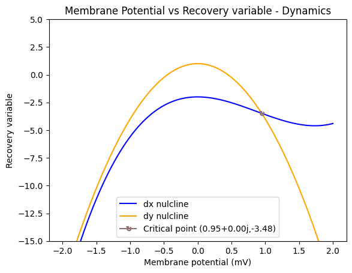

```python
plt.plot(x, dx_nul_vals, color=X_NUL_COLOR,
         label=X_NUL_LABEL)
plt.plot(x, dy_nul_vals, color=Y_NUL_COLOR,
         label=Y_NUL_LABEL)

plt = plot_critical_points(
    plt, [c_1], [CRIT_POINT_UNSTABLE_SPIRAL_MARKER],
    CRIT_POINT_COLOR, CRIT_POINT_LABEL)


plt = add_plot_properties(plt, x_label=OX_LABEL,
                          y_label=OY_LABEL,
                          title=TITLE,
                          y_lim=y_lim)

plt.legend()
```

## Phase Space

```python
# common values
x = np.linspace(x_start, x_stop, values)
y = np.linspace(y_start, y_stop, values)

X, Y = np.mgrid[x_start:x_stop:n_arrows, y_start:y_stop:n_arrows]

# t=0 because is an autonomous system
dx, dy = hr_dt(
    (X, Y), 0, a, b, c, d,
    pulse_times, i_0, i_inf, z)
```

[output not shown]

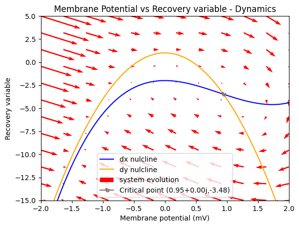

```python
y_factor = 1
x_factor = 3

plot_phase_space(
    plt, x_lim, y_lim, OX_LABEL, OY_LABEL, TITLE, x, X, Y, dx_nul_vals,
    X_NUL_COLOR, X_NUL_LABEL, dy_nul_vals, Y_NUL_COLOR, Y_NUL_LABEL,
    dx, x_factor, dy, y_factor, ARROWS_COLOR, ARROWS_LABEL,
    [c_1], [CRIT_POINT_UNSTABLE_SPIRAL_MARKER], CRIT_POINT_COLOR,
    CRIT_POINT_LABEL)
```

### Critical points stability

As we shown in the last graphic, we have a series of critical points which types we are going to discuss here.

Here we are going to study them visually and obtaining their eigenvalues.

Before working on these points we should compute the Jacobian of our dynamical system:

$$ \begin{gather*} \mathbb{J}_{\dot x, \dot y} = \begin{bmatrix} \frac{\partial \dot x}{\partial x} & \frac{\partial \dot x}{\partial y} \\ \frac{\partial \dot y}{\partial x} & \frac{\partial \dot y}{\partial y} \end{bmatrix} = \begin{bmatrix} -3Ax^2 + 2Bx & 1 \\ -2Dx & -1 \end{bmatrix} \end{gather*} $$

Having:

$$ \begin{gather*} &\text{Having:}& \\ A = 1, & B = 2.6, & C = 1 \\ D = 5, & I(\infty) = 2, & I_0 = 1 \end{gather*} $$

Then: $$ \begin{gather*}

\begin{bmatrix} -3x^2 + 5.2x & 1 \\ -10x & -1 \end{bmatrix}

\end{gather*} $$

```python
# common values
default_params =\
    {
        't': 0,
        'a': A,
        'b': B,
        'c': C,
        'd': D,
        'pulse_times': deque(),
        'i': I_INF,
        'i_0': I_0,
        'i_inf': I_INF,
        'z': Z,
        'dx_nul': dx_nul,
        'dy_nul': dy_nul,
        'dyn_sys': hr_dt
    }

# jacobian
jacobian = lambda x, y: np.array(
    [
        [-3 * (x*x) + 5.2*x, 1],
        [-10*x, -1]
    ]
)
```

#### Critical point (0.95, -3.48)

##### Eigenvalues interpretation

Now we have to obtain the eigenvalues of:

$$ \begin{gather*} \begin{bmatrix} -3x^2 + 5.2x & 1 \\ -10x & -1 \end{bmatrix} \end{gather*} $$

But we must find them in the point: $$ (0.95, -3.48) $$

As we can see in the cell below, we obtain the following eigenvalues:

```python
eigvals, _ = eig(jacobian(c_1[0], c_1[1]))
eigvals
```

```
array([0.61704038+2.61781238j, 0.61704038-2.61781238j])
```

We can see that both real parts are the same, but it imaginary parts are negative and positive (conjugated), that means we are in front of a **unstable focus**!

# Bifurcation diagram

Here we will see how the dynamics of the system change with different parameters.

## Bifurcation diagram on parameter `z`

### Summary

We should remember that our system dynamics are described as:

$$ \begin{gather*} \dot x = y - Ax^3 + Bx^2 + I_\infty - z \\ \dot y = C - Dx^2 - y \end{gather*} $$$$ \begin{gather*} \text{The $\textbf{default}$ constant values will be (except $z$):} \\ \end{gather*} $$$$ \begin{gather*} A = 1, & B = 2.6, & C = 1, & D = 5 & I_\infty = 2 \\ \end{gather*} $$$$ \begin{gather*} \text{So, in other words:} \\ \dot x = y - x^3 + 2.6x^2 + 2 - z \\ \dot y = 1 - 5x^2 - y \end{gather*} $$$$ \begin{gather*} &\text{dx nulcline $(y_1)$:}& \\ &y = Ax^3 - Bx^2 - I(\infty) + z& \\ \\ &\text{dy nulcline $(y_2)$:}& \\ &y = C - Dx^2& \\ \end{gather*} $$

Moreover (for any $z$):

$$ \begin{gather*} \mathbb{J}_{\dot x, \dot y} = \begin{bmatrix} \frac{\partial \dot x}{\partial x} & \frac{\partial \dot x}{\partial y} \\ \frac{\partial \dot y}{\partial x} & \frac{\partial \dot y}{\partial y} \end{bmatrix} = \begin{bmatrix} -3Ax^2 + 2Bx & 1 \\ -2Dx & -1 \end{bmatrix} = \begin{bmatrix} -3x^2 + 5.2x & 1 \\ -10x & -1 \end{bmatrix} \end{gather*} $$

## Approach

To study the system stablity of its equilibrium points we could give our system 10 values of $z$ and try to predict how does it behaves in different conditions.

We will try the following values: $$ z \in \{-4, -3, -2, -1, 0, 1, 2, 3, 4, 5\} $$

After doing that we will try to conclude the bifurcation diagram.

```python
# we will leave all the system in function of "x"
x_start, x_stop = (-2, 2)
y_start, y_stop = (-15, 5)

values = 1000
x = np.linspace(x_start, x_stop, values)

# plot utilities
x_lim = (x_start, x_stop)
y_lim = (y_start, y_stop)

# common values for all the systems
common_z_vals =\
    {
        't': 0,
        'a': A,
        'b': B,
        'c': C,
        'd': D,
        'pulse_times': deque(),
        'i': I_INF,
        'i_0': I_0,
        'i_inf': I_INF,
        'z': Z,
        'dx_nul': dx_nul,
        'dy_nul': dy_nul,
        'dyn_sys': hr_dt
    }
```

### Negative values

#### $z = -4$

#### Parameters

```python
common_z_vals = common_z_vals.copy()
common_z_vals['z'] = -4
```

#### Critical points

$$ z = -4 $$$$ \begin{gather*} \text{Nulclines:} \\ y_1 = Ax^3 - Bx^2 - I(\infty) + z = x^3 - 2.6x^2 - 2 - 4 = x^3 - 2.6x^2 - 6 \\ y_2 = C - Dx^2 = 1 - 5x^2 \\ \end{gather*} $$$$ \begin{gather*} &\text{Equation to solve:}& \\ &x^2(x - 2.6 + 5) = 1 + 2 - (-4)& \\ &x^2(x + 2.4) = 7& \\ \end{gather*} $$

```python
y_1 = lambda x: common_z_vals['a']*x*x*x -\
    common_z_vals['b']*x*x - common_z_vals['i_inf'] + common_z_vals['z']
y_2 = lambda x: common_z_vals['c'] - common_z_vals['d']*x*x

equations = [y_1, y_2]
coefs = [1, 2.4, 0, -7]

x_sols, equations_sols =\
    obtain_critical_points(coefs, equations)

print_equations(common_z_vals['i_inf'], common_z_vals['z'], x_sols, equations_sols)

y_sols = equations_sols[0]

# Critical points
c_1 = (x_sols[0], y_sols[0])
```

```
First equation: y_1 = lambda x: x*x*x - 2.6*x*x - 6
	Solutions:
	 x: [1.36376029+0.j]
	 y: [-8.2992107]

Second equation: y_2 = lambda x: 1 - 5*x*x
	Solutions:
	 x: [1.36376029+0.j]
	 y: [-8.2992107]

They are both the same!
```

#### Plot visualization

> **Note**

> Our notation for stable, unstable, ..., points will be:
> - CRIT_POINT_STABLE_MARKER = 'o' -> Stable nodes.
> - CRIT_POINT_SADDLE_MARKER = '$\diamondsuit$' -> Saddle-Points.
> - CRIT_POINT_UNSTABLE_SPIRAL_MARKER = '$\circlearrowright$' -> Unstable Focus.
> - CRIT_POINT_NON_ISOLATED_MARKER = '+' -> Non-isolated equilibrium.

```python
x_window, y_window, ox, X, Y, dx_nul_vals, dy_nul_vals, dx, dy =\
    prepare_phase_space_values(
        [-5, 6], [-70, 60], n_arrows=12j, values=1000, **common_z_vals)
```

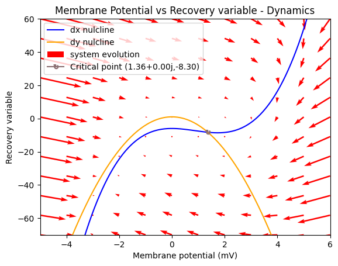

```python
y_factor = 1
x_factor = 3

plt = plot_phase_space(
    plt, x_window, y_window, OX_LABEL, OY_LABEL, TITLE, ox, X, Y, dx_nul_vals,
    X_NUL_COLOR, X_NUL_LABEL, dy_nul_vals, Y_NUL_COLOR, Y_NUL_LABEL,
    dx, x_factor, dy, y_factor, ARROWS_COLOR, ARROWS_LABEL,
    [c_1], [CRIT_POINT_UNSTABLE_SPIRAL_MARKER], CRIT_POINT_COLOR, CRIT_POINT_LABEL)

plt.show()
```

#### Critical point stability

With the previously mentioned jacobian: $$ \begin{gather*} \mathbb{J}_{\dot x, \dot y} = \begin{bmatrix} -3x^2 + 5.2x & 1 \\ -10x & -1 \end{bmatrix} \end{gather*} $$

We must find the eigenvalues on the point: $$ (1.36, -8.30) $$

As we can see in the cell below, we obtain the following eigenvalues:

```python
eigvals, _ = eig(jacobian(c_1[0], c_1[1]))
eigvals
```

```
array([0.25601355+3.47275581j, 0.25601355-3.47275581j])
```

We can see that both real parts are the same, but it imaginary parts are negative and positive (conjugated), that means we are in front of a **unstable focus**!

#### $z=-3$

#### Parameters

```python
common_z_vals = common_z_vals.copy()
common_z_vals['z'] = -3
```

#### Critical points

$$ z = -3 $$$$ \begin{gather*} \text{Nulclines:} \\ y_1 = Ax^3 - Bx^2 - I(\infty) + z = x^3 - 2.6x^2 - 2 - 3 = x^3 - 2.6x^2 - 5 \\ y_2 = C - Dx^2 = 1 - 5x^2 \\ \end{gather*} $$$$ \begin{gather*} &\text{Equation to solve:}& \\ &x^2(x - 2.6 + 5) = 1 + 2 - (-3)& \\ &x^2(x + 2.4) = 6& \\ \end{gather*} $$

```python
y_1 = lambda x: common_z_vals['a']*x*x*x -\
    common_z_vals['b']*x*x - common_z_vals['i_inf'] + common_z_vals['z']
y_2 = lambda x: common_z_vals['c'] - common_z_vals['d']*x*x

equations = [y_1, y_2]
coefs = [1, 2.4, 0, -6]

x_sols, equations_sols =\
    obtain_critical_points(coefs, equations)

print_equations(common_z_vals['i_inf'], common_z_vals['z'], x_sols, equations_sols)

y_sols = equations_sols[0]

# Critical points
c_1 = (x_sols[0], y_sols[0])
```

```
First equation: y_1 = lambda x: x*x*x - 2.6*x*x - 5
	Solutions:
	 x: [1.27734556+0.j]
	 y: [-7.15805844]

Second equation: y_2 = lambda x: 1 - 5*x*x
	Solutions:
	 x: [1.27734556+0.j]
	 y: [-7.15805844]

They are both the same!
```

#### Plot visualization

> **Note**

> Our notation for stable, unstable, ..., points will be:
> - CRIT_POINT_STABLE_MARKER = 'o' -> Stable nodes.
> - CRIT_POINT_SADDLE_MARKER = '$\diamondsuit$' -> Saddle-Points.
> - CRIT_POINT_UNSTABLE_SPIRAL_MARKER = '$\circlearrowright$' -> Unstable Focus.
> - CRIT_POINT_NON_ISOLATED_MARKER = '+' -> Non-isolated equilibrium.

```python
x_window, y_window, ox, X, Y, dx_nul_vals, dy_nul_vals, dx, dy =\
    prepare_phase_space_values(
        [-5, 6], [-70, 60], n_arrows=12j, values=1000, **common_z_vals)
```

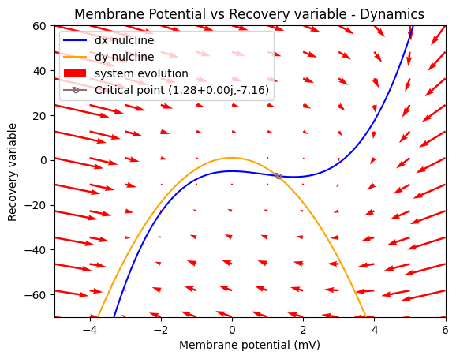

```python
y_factor = 1
x_factor = 3

plt = plot_phase_space(
    plt, x_window, y_window, OX_LABEL, OY_LABEL, TITLE, ox, X, Y, dx_nul_vals,
    X_NUL_COLOR, X_NUL_LABEL, dy_nul_vals, Y_NUL_COLOR, Y_NUL_LABEL,
    dx, x_factor, dy, y_factor, ARROWS_COLOR, ARROWS_LABEL,
    [c_1], [CRIT_POINT_UNSTABLE_SPIRAL_MARKER], CRIT_POINT_COLOR, CRIT_POINT_LABEL)

plt.show()
```

#### Critical point stability

With the previously mentioned jacobian: $$ \begin{gather*} \mathbb{J}_{\dot x, \dot y} = \begin{bmatrix} -3x^2 + 5.2x & 1 \\ -10x & -1 \end{bmatrix} \end{gather*} $$

We must find the eigenvalues on the point: $$ (1.28, -7.16) $$

As we can see in the cell below, we obtain the following eigenvalues:

```python
eigvals, _ = eig(jacobian(c_1[0], c_1[1]))
eigvals
```

```
array([0.37368093+3.29946304j, 0.37368093-3.29946304j])
```

We can see that both real parts are the same, but it imaginary parts are negative and positive (conjugated), that means we are in front of a **unstable focus**!

#### $z=-2$

#### Parameters

```python
common_z_vals = common_z_vals.copy()
common_z_vals['z'] = -2
```

#### Critical points

$$ z = -2 $$$$ \begin{gather*} \text{Nulclines:} \\ y_1 = Ax^3 - Bx^2 - I(\infty) + z = x^3 - 2.6x^2 - 2 - 2 = x^3 - 2.6x^2 - 4 \\ y_2 = C - Dx^2 = 1 - 5x^2 \\ \end{gather*} $$$$ \begin{gather*} &\text{Equation to solve:}& \\ &x^2(x - 2.6 + 5) = 1 + 2 - (-2)& \\ &x^2(x + 2.4) = 5& \\ \end{gather*} $$

```python
y_1 = lambda x: common_z_vals['a']*x*x*x -\
    common_z_vals['b']*x*x - common_z_vals['i_inf'] + common_z_vals['z']
y_2 = lambda x: common_z_vals['c'] - common_z_vals['d']*x*x

equations = [y_1, y_2]
coefs = [1, 2.4, 0, -5]

x_sols, equations_sols =\
    obtain_critical_points(coefs, equations)

print_equations(common_z_vals['i_inf'], common_z_vals['z'], x_sols, equations_sols)

y_sols = equations_sols[0]

# Critical points
c_1 = (x_sols[0], y_sols[0])
```

```
First equation: y_1 = lambda x: x*x*x - 2.6*x*x - 4
	Solutions:
	 x: [1.1815439+0.j]
	 y: [-5.98022995]

Second equation: y_2 = lambda x: 1 - 5*x*x
	Solutions:
	 x: [1.1815439+0.j]
	 y: [-5.98022995]

They are both the same!
```

#### Plot visualization

> **Note**

> Our notation for stable, unstable, ..., points will be:
> - CRIT_POINT_STABLE_MARKER = 'o' -> Stable nodes.
> - CRIT_POINT_SADDLE_MARKER = '$\diamondsuit$' -> Saddle-Points.
> - CRIT_POINT_UNSTABLE_SPIRAL_MARKER = '$\circlearrowright$' -> Unstable Focus.
> - CRIT_POINT_NON_ISOLATED_MARKER = '+' -> Non-isolated equilibrium.

```python
x_window, y_window, ox, X, Y, dx_nul_vals, dy_nul_vals, dx, dy =\
    prepare_phase_space_values(
        [-5, 6], [-70, 60], n_arrows=12j, values=1000, **common_z_vals)
```

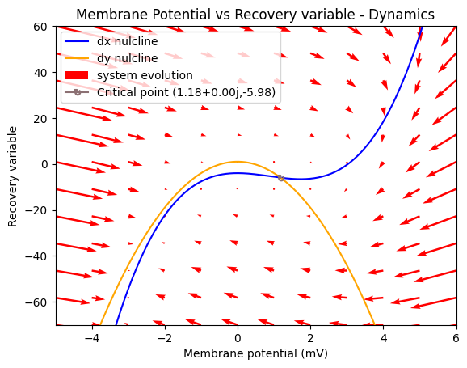

```python
y_factor = 1
x_factor = 3

plt = plot_phase_space(
    plt, x_window, y_window, OX_LABEL, OY_LABEL, TITLE, ox, X, Y, dx_nul_vals,
    X_NUL_COLOR, X_NUL_LABEL, dy_nul_vals, Y_NUL_COLOR, Y_NUL_LABEL,
    dx, x_factor, dy, y_factor, ARROWS_COLOR, ARROWS_LABEL,
    [c_1], [CRIT_POINT_UNSTABLE_SPIRAL_MARKER], CRIT_POINT_COLOR, CRIT_POINT_LABEL)

plt.show()
```

#### Critical point stability

With the previously mentioned jacobian: $$ \begin{gather*} \mathbb{J}_{\dot x, \dot y} = \begin{bmatrix} -3x^2 + 5.2x & 1 \\ -10x & -1 \end{bmatrix} \end{gather*} $$

We must find the eigenvalues on the point: $$ (1.18, -5.98) $$

As we can see in the cell below, we obtain the following eigenvalues:

```python
eigvals, _ = eig(jacobian(c_1[0], c_1[1]))
eigvals
```

```
array([0.47794516+3.10340412j, 0.47794516-3.10340412j])
```

We can see that both real parts are the same, but it imaginary parts are negative and positive (conjugated), that means we are in front of a **unstable focus**!

#### $z=-1$

#### Parameters

```python
common_z_vals = common_z_vals.copy()
common_z_vals['z'] = -1
```

#### Critical points

$$ z = -1 $$$$ \begin{gather*} \text{Nulclines:} \\ y_1 = Ax^3 - Bx^2 - I(\infty) + z = x^3 - 2.6x^2 - 2 - 1 = x^3 - 2.6x^2 - 3 \\ y_2 = C - Dx^2 = 1 - 5x^2 \\ \end{gather*} $$$$ \begin{gather*} &\text{Equation to solve:}& \\ &x^2(x - 2.6 + 5) = 1 + 2 - (-1)& \\ &x^2(x + 2.4) = 4& \\ \end{gather*} $$

```python
y_1 = lambda x: common_z_vals['a']*x*x*x -\
    common_z_vals['b']*x*x - common_z_vals['i_inf'] + common_z_vals['z']
y_2 = lambda x: common_z_vals['c'] - common_z_vals['d']*x*x

equations = [y_1, y_2]
coefs = [1, 2.4, 0, -4]

x_sols, equations_sols =\
    obtain_critical_points(coefs, equations)

print_equations(common_z_vals['i_inf'], common_z_vals['z'], x_sols, equations_sols)

y_sols = equations_sols[0]

# Critical points
c_1 = (x_sols[0], y_sols[0])
```

```
First equation: y_1 = lambda x: x*x*x - 2.6*x*x - 3
	Solutions:
	 x: [1.07316669+0.j]
	 y: [-4.75843367]

Second equation: y_2 = lambda x: 1 - 5*x*x
	Solutions:
	 x: [1.07316669+0.j]
	 y: [-4.75843367]

They are both the same!
```

#### Plot visualization

> **Note**

> Our notation for stable, unstable, ..., points will be:
> - CRIT_POINT_STABLE_MARKER = 'o' -> Stable nodes.
> - CRIT_POINT_SADDLE_MARKER = '$\diamondsuit$' -> Saddle-Points.
> - CRIT_POINT_UNSTABLE_SPIRAL_MARKER = '$\circlearrowright$' -> Unstable Focus.
> - CRIT_POINT_NON_ISOLATED_MARKER = '+' -> Non-isolated equilibrium.

```python
x_window, y_window, ox, X, Y, dx_nul_vals, dy_nul_vals, dx, dy =\
    prepare_phase_space_values(
        [-5, 6], [-70, 60], n_arrows=12j, values=1000, **common_z_vals)
```

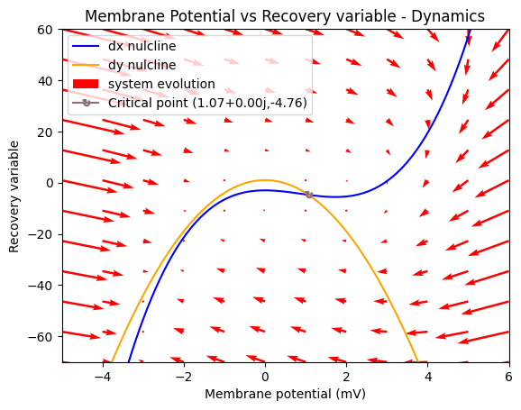

```python
y_factor = 1
x_factor = 3

plt = plot_phase_space(
    plt, x_window, y_window, OX_LABEL, OY_LABEL, TITLE, ox, X, Y, dx_nul_vals,
    X_NUL_COLOR, X_NUL_LABEL, dy_nul_vals, Y_NUL_COLOR, Y_NUL_LABEL,
    dx, x_factor, dy, y_factor, ARROWS_COLOR, ARROWS_LABEL,
    [c_1], [CRIT_POINT_UNSTABLE_SPIRAL_MARKER], CRIT_POINT_COLOR, CRIT_POINT_LABEL)

plt.show()
```

#### Critical point stability

With the previously mentioned jacobian: $$ \begin{gather*} \mathbb{J}_{\dot x, \dot y} = \begin{bmatrix} -3x^2 + 5.2x & 1 \\ -10x & -1 \end{bmatrix} \end{gather*} $$

As we can see in the cell below, we obtain the following eigenvalues:

```python
eigvals, _ = eig(jacobian(c_1[0], c_1[1]))
eigvals
```

```
array([0.56270328+2.87917094j, 0.56270328-2.87917094j])
```

We can see that both real parts are the same, but it imaginary parts are negative and positive (conjugated), that means we are in front of a **unstable focus**!

### Positive values

#### $z=0$

#### Parameters

```python
common_z_vals = common_z_vals.copy()
common_z_vals['z'] = 0
```

#### Critical points

$$ z = 0 $$$$ \begin{gather*} \text{Nulclines:} \\ y_1 = Ax^3 - Bx^2 - I(\infty) + z = x^3 - 2.6x^2 - 2 + 0 = x^3 - 2.6x^2 - 2 \\ y_2 = C - Dx^2 = 1 - 5x^2 \\ \end{gather*} $$$$ \begin{gather*} &\text{Equation to solve:}& \\ &x^2(x - 2.6 + 5) = 1 + 2 - 0& \\ &x^2(x + 2.4) = 3& \\ \end{gather*} $$

```python
y_1 = lambda x: common_z_vals['a']*x*x*x -\
    common_z_vals['b']*x*x - common_z_vals['i_inf'] + common_z_vals['z']
y_2 = lambda x: common_z_vals['c'] - common_z_vals['d']*x*x

equations = [y_1, y_2]
coefs = [1, 2.4, 0, -3]

x_sols, equations_sols =\
    obtain_critical_points(coefs, equations)

print_equations(common_z_vals['i_inf'], common_z_vals['z'], x_sols, equations_sols)

y_sols = equations_sols[0]

# Critical points
c_1 = (x_sols[0], y_sols[0])
```

```
First equation: y_1 = lambda x: x*x*x - 2.6*x*x - 2
	Solutions:
	 x: [0.94677612+0.j]
	 y: [-3.48192513]

Second equation: y_2 = lambda x: 1 - 5*x*x
	Solutions:
	 x: [0.94677612+0.j]
	 y: [-3.48192513]

They are both the same!
```

#### Plot visualization

> **Note**

> Our notation for stable, unstable, ..., points will be:
> - CRIT_POINT_STABLE_MARKER = 'o' -> Stable nodes.
> - CRIT_POINT_SADDLE_MARKER = '$\diamondsuit$' -> Saddle-Points.
> - CRIT_POINT_UNSTABLE_SPIRAL_MARKER = '$\circlearrowright$' -> Unstable Focus.
> - CRIT_POINT_NON_ISOLATED_MARKER = '+' -> Non-isolated equilibrium.

```python
x_window, y_window, ox, X, Y, dx_nul_vals, dy_nul_vals, dx, dy =\
    prepare_phase_space_values(
        [-5, 6], [-70, 60], n_arrows=12j, values=1000, **common_z_vals)
```

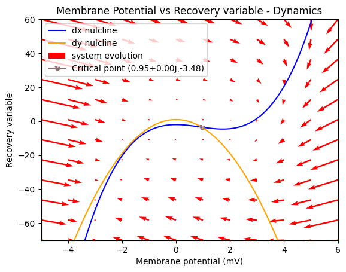

```python
y_factor = 1
x_factor = 3

plt = plot_phase_space(
    plt, x_window, y_window, OX_LABEL, OY_LABEL, TITLE, ox, X, Y, dx_nul_vals,
    X_NUL_COLOR, X_NUL_LABEL, dy_nul_vals, Y_NUL_COLOR, Y_NUL_LABEL,
    dx, x_factor, dy, y_factor, ARROWS_COLOR, ARROWS_LABEL,
    [c_1], [CRIT_POINT_UNSTABLE_SPIRAL_MARKER], CRIT_POINT_COLOR, CRIT_POINT_LABEL)

plt.show()
```

#### Critical point stability

With the previously mentioned jacobian: $$ \begin{gather*} \mathbb{J}_{\dot x, \dot y} = \begin{bmatrix} -3x^2 + 5.2x & 1 \\ -10x & -1 \end{bmatrix} \end{gather*} $$

We must find the eigenvalues on the point: $$ (0.95, -3.48) $$

As we can see in the cell below, we obtain the following eigenvalues:

```python
eigvals, _ = eig(jacobian(c_1[0], c_1[1]))
eigvals
```

```
array([0.61704038+2.61781238j, 0.61704038-2.61781238j])
```

We can see that both real parts are the same, but it imaginary parts are negative and positive (conjugated), that means we are in front of a **unstable focus**!

#### $z=1$

#### Parameters

```python
common_z_vals = common_z_vals.copy()
common_z_vals['z'] = 1
```

#### Critical points

$$ z = 1 $$$$ \begin{gather*} \text{Nulclines:} \\ y_1 = Ax^3 - Bx^2 - I(\infty) + z = x^3 - 2.6x^2 - 2 + 1 = x^3 - 2.6x^2 - 1 \\ y_2 = C - Dx^2 = 1 - 5x^2 \\ \end{gather*} $$$$ \begin{gather*} &\text{Equation to solve:}& \\ &x^2(x - 2.6 + 5) = 1 + 2 - 1& \\ &x^2(x + 2.4) = 2& \\ \end{gather*} $$

```python
y_1 = lambda x: common_z_vals['a']*x*x*x -\
    common_z_vals['b']*x*x - common_z_vals['i_inf'] + common_z_vals['z']
y_2 = lambda x: common_z_vals['c'] - common_z_vals['d']*x*x

equations = [y_1, y_2]
coefs = [1, 2.4, 0, -2]

x_sols, equations_sols =\
    obtain_critical_points(coefs, equations)

print_equations(common_z_vals['i_inf'], common_z_vals['z'], x_sols, equations_sols)

y_sols = equations_sols[0]

# Critical points
c_1 = (x_sols[0], y_sols[0])
c_2 = (x_sols[1], y_sols[1])
c_3 = (x_sols[2], y_sols[2])
```

```
First equation: y_1 = lambda x: x*x*x - 2.6*x*x - 1
	Solutions:
	 x: [-1.73753542 -1.45407266  0.79160808]
	 y: [-14.0951467   -9.57163652  -2.13321678]

Second equation: y_2 = lambda x: 1 - 5*x*x
	Solutions:
	 x: [-1.73753542 -1.45407266  0.79160808]
	 y: [-14.0951467   -9.57163652  -2.13321678]

They are both the same!
```

#### Plot visualization

> **Note**

> Our notation for stable, unstable, ..., points will be:
> - CRIT_POINT_STABLE_MARKER = 'o' -> Stable nodes.
> - CRIT_POINT_SADDLE_MARKER = '$\diamondsuit$' -> Saddle-Points.
> - CRIT_POINT_UNSTABLE_SPIRAL_MARKER = '$\circlearrowright$' -> Unstable Focus.
> - CRIT_POINT_NON_ISOLATED_MARKER = '+' -> Non-isolated equilibrium.

```python
x_window, y_window, ox, X, Y, dx_nul_vals, dy_nul_vals, dx, dy =\
    prepare_phase_space_values(
        [-5, 6], [-70, 60], n_arrows=12j, values=1000, **common_z_vals)
```

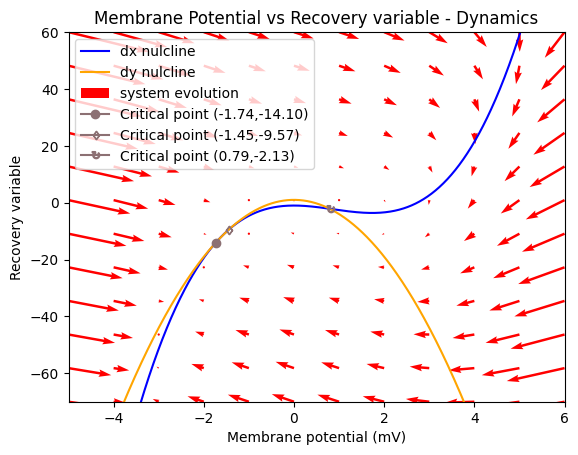

```python
y_factor = 1
x_factor = 3

plt = plot_phase_space(
    plt, x_window, y_window, OX_LABEL, OY_LABEL, TITLE, ox, X, Y, dx_nul_vals,
    X_NUL_COLOR, X_NUL_LABEL, dy_nul_vals, Y_NUL_COLOR, Y_NUL_LABEL,
    dx, x_factor, dy, y_factor, ARROWS_COLOR, ARROWS_LABEL,
    [c_1,c_2,c_3],\
    [CRIT_POINT_STABLE_MARKER,CRIT_POINT_SADDLE_MARKER,CRIT_POINT_UNSTABLE_SPIRAL_MARKER],\
    CRIT_POINT_COLOR, CRIT_POINT_LABEL)

plt.show()
```

#### Critical point stability (c1)

With the previously mentioned jacobian: $$ \begin{gather*} \mathbb{J}_{\dot x, \dot y} = \begin{bmatrix} -3x^2 + 5.2x & 1 \\ -10x & -1 \end{bmatrix} \end{gather*} $$

We must find the eigenvalues on the point: $$ (-1.74, -14.1) $$

As we can see in the cell below, we obtain the following eigenvalues:

```python
eigvals, _ = eig(jacobian(c_1[0], c_1[1]))
eigvals
```

```
array([-19.0546479 ,  -0.03762431])
```

We can see that both are negative real values, so we are talking about a stable node!

#### Critical point stability (c2)

With the previously mentioned jacobian: $$ \begin{gather*} \mathbb{J}_{\dot x, \dot y} = \begin{bmatrix} -3x^2 + 5.2x & 1 \\ -10x & -1 \end{bmatrix} \end{gather*} $$

We must find the eigenvalues on the point: $$ (-1.45, -9.57) $$

As we can see in the cell below, we obtain the following eigenvalues:

```python
eigvals, _ = eig(jacobian(c_2[0], c_2[1]))
eigvals
```

```
array([-14.94674873,   0.04258899])
```

We can see that both are real numbers, but with different sign, that means we are in front of a **saddle point**!

#### Critical point stability (c3)

With the previously mentioned jacobian: $$ \begin{gather*} \mathbb{J}_{\dot x, \dot y} = \begin{bmatrix} -3x^2 + 5.2x & 1 \\ -10x & -1 \end{bmatrix} \end{gather*} $$

We must find the eigenvalues on the point: $$ (0.79, -2.13) $$

As we can see in the cell below, we obtain the following eigenvalues:

```python
eigvals, _ = eig(jacobian(c_3[0], c_3[1]))
eigvals
```

```
array([0.61821598+2.3016207j, 0.61821598-2.3016207j])
```

We can see that both are complex numbers **with the same real part (of positive sign)**, but whose **imaginary part is conjugated**! That means we are in front of a **unstable focus**!

#### $z=2$

#### Parameters

```python
common_z_vals = common_z_vals.copy()
common_z_vals['z'] = 2
```

#### Critical points

$$ z = 2 $$$$ \begin{gather*} \text{Nulclines:} \\ y_1 = Ax^3 - Bx^2 - I(\infty) + z = x^3 - 2.6x^2 - 2 + 2 = x^3 - 2.6x^2 \\ y_2 = C - Dx^2 = 1 - 5x^2 \\ \end{gather*} $$$$ \begin{gather*} &\text{Equation to solve:}& \\ &x^2(x - 2.6 + 5) = 1 + 2 - 2& \\ &x^2(x + 2.4) = 1& \\ \end{gather*} $$

```python
y_1 = lambda x: common_z_vals['a']*x*x*x -\
    common_z_vals['b']*x*x - common_z_vals['i_inf'] + common_z_vals['z']
y_2 = lambda x: common_z_vals['c'] - common_z_vals['d']*x*x

equations = [y_1, y_2]
coefs = [1, 2.4, 0, -1]

x_sols, equations_sols =\
    obtain_critical_points(coefs, equations)

print_equations(common_z_vals['i_inf'], common_z_vals['z'], x_sols, equations_sols)

y_sols = equations_sols[0]

# Critical points
c_1 = (x_sols[0], y_sols[0])
c_2 = (x_sols[1], y_sols[1])
c_3 = (x_sols[2], y_sols[2])
```

```
First equation: y_1 = lambda x: x*x*x - 2.6*x*x
	Solutions:
	 x: [-2.19184886 -0.78749898  0.57934784]
	 y: [-23.02100714  -2.10077324  -0.67821962]

Second equation: y_2 = lambda x: 1 - 5*x*x
	Solutions:
	 x: [-2.19184886 -0.78749898  0.57934784]
	 y: [-23.02100714  -2.10077324  -0.67821962]

They are both the same!
```

#### Plot visualization

> **Note**

> Our notation for stable, unstable, ..., points will be:
> - CRIT_POINT_STABLE_MARKER = 'o' -> Stable nodes.
> - CRIT_POINT_SADDLE_MARKER = '$\diamondsuit$' -> Saddle-Points.
> - CRIT_POINT_UNSTABLE_SPIRAL_MARKER = '$\circlearrowright$' -> Unstable Focus.
> - CRIT_POINT_NON_ISOLATED_MARKER = '+' -> Non-isolated equilibrium.

```python
x_window, y_window, ox, X, Y, dx_nul_vals, dy_nul_vals, dx, dy =\
    prepare_phase_space_values(
        [-5, 6], [-70, 60], n_arrows=12j, values=1000, **common_z_vals)
```

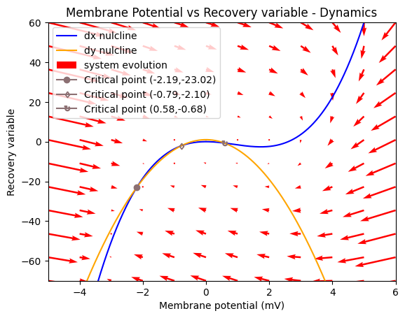

```python
y_factor = 1
x_factor = 3

plt = plot_phase_space(
    plt, x_window, y_window, OX_LABEL, OY_LABEL, TITLE, ox, X, Y, dx_nul_vals,
    X_NUL_COLOR, X_NUL_LABEL, dy_nul_vals, Y_NUL_COLOR, Y_NUL_LABEL,
    dx, x_factor, dy, y_factor, ARROWS_COLOR, ARROWS_LABEL,
    [c_1,c_2,c_3],\
    [CRIT_POINT_STABLE_MARKER,CRIT_POINT_SADDLE_MARKER,CRIT_POINT_UNSTABLE_SPIRAL_MARKER],\
    CRIT_POINT_COLOR, CRIT_POINT_LABEL)

plt.show()
```

#### Critical point stability (c1)

With the previously mentioned jacobian: $$ \begin{gather*} \mathbb{J}_{\dot x, \dot y} = \begin{bmatrix} -3x^2 + 5.2x & 1 \\ -10x & -1 \end{bmatrix} \end{gather*} $$

We must find the eigenvalues on the point: $$ (-2.19, -23.02) $$

As we can see in the cell below, we obtain the following eigenvalues:

```python
eigvals, _ = eig(jacobian(c_1[0], c_1[1]))
eigvals
```

```
array([-26.66426535,  -0.14595301])
```

We can see that both are negative real values, so we are talking about a stable node!

#### Critical point stability (c2)

With the previously mentioned jacobian: $$ \begin{gather*} \mathbb{J}_{\dot x, \dot y} = \begin{bmatrix} -3x^2 + 5.2x & 1 \\ -10x & -1 \end{bmatrix} \end{gather*} $$

We must find the eigenvalues on the point: $$ (-0.79, -2.1) $$

As we can see in the cell below, we obtain the following eigenvalues:

```python
eigvals, _ = eig(jacobian(c_2[0], c_2[1]))
eigvals
```

```
array([-7.22127476,  0.26581611])
```

We can see that both are real numbers, but with different sign, that means we are in front of a **saddle point**!

#### Critical point stability (c3)

With the previously mentioned jacobian: $$ \begin{gather*} \mathbb{J}_{\dot x, \dot y} = \begin{bmatrix} -3x^2 + 5.2x & 1 \\ -10x & -1 \end{bmatrix} \end{gather*} $$

We must find the eigenvalues on the point: $$ (0.58, -0.68) $$

As we can see in the cell below, we obtain the following eigenvalues:

```python
eigvals, _ = eig(jacobian(c_3[0], c_3[1]))
eigvals
```

```
array([0.50283851+1.88014756j, 0.50283851-1.88014756j])
```

We can see that both are complex numbers **with the same real part (of positive sign)**, but whose **imaginary part is conjugated**! That means we are in front of a **unstable focus**!

#### $z=3$

#### Parameters

```python
common_z_vals = common_z_vals.copy()
common_z_vals['z'] = 3
```

#### Critical points

$$ z = 3 $$$$ \begin{gather*} \text{Nulclines:} \\ y_1 = Ax^3 - Bx^2 - I(\infty) + z = x^3 - 2.6x^2 - 2 + 3 = x^3 - 2.6x^2 + 1 \\ y_2 = C - Dx^2 = 1 - 5x^2 \\ \end{gather*} $$$$ \begin{gather*} &\text{Equation to solve:}& \\ &x^2(x - 2.6 + 5) = 1 + 2 - 3& \\ &x^2(x + 2.4) = 0& \\ \end{gather*} $$

```python
y_1 = lambda x: common_z_vals['a']*x*x*x -\
    common_z_vals['b']*x*x - common_z_vals['i_inf'] + common_z_vals['z']
y_2 = lambda x: common_z_vals['c'] - common_z_vals['d']*x*x

equations = [y_1, y_2]
coefs = [1, 2.4, 0, 0]

x_sols, equations_sols =\
    obtain_critical_points(coefs, equations)

print_equations(common_z_vals['i_inf'], common_z_vals['z'], x_sols, equations_sols)

y_sols = equations_sols[0]

# Critical points
c_1 = (x_sols[0], y_sols[0])
c_2 = (x_sols[1], y_sols[1])
```

```
First equation: y_1 = lambda x: x*x*x - 2.6*x*x + 1
	Solutions:
	 x: [-2.4  0.   0. ]
	 y: [-27.8   1.    1. ]

Second equation: y_2 = lambda x: 1 - 5*x*x
	Solutions:
	 x: [-2.4  0.   0. ]
	 y: [-27.8   1.    1. ]

They are both the same!
```

#### Plot visualization

> **Note**

> Our notation for stable, unstable, ..., points will be:
> - CRIT_POINT_STABLE_MARKER = 'o' -> Stable nodes.
> - CRIT_POINT_SADDLE_MARKER = '$\diamondsuit$' -> Saddle-Points.
> - CRIT_POINT_UNSTABLE_SPIRAL_MARKER = '$\circlearrowright$' -> Unstable Focus.
> - CRIT_POINT_NON_ISOLATED_MARKER = '+' -> Non-isolated equilibrium.

```python
x_window, y_window, ox, X, Y, dx_nul_vals, dy_nul_vals, dx, dy =\
    prepare_phase_space_values(
        [-5, 6], [-70, 60], n_arrows=12j, values=1000, **common_z_vals)
```

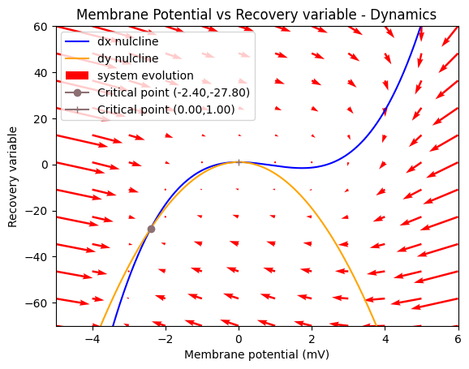

```python
y_factor = 1
x_factor = 3

plt = plot_phase_space(
    plt, x_window, y_window, OX_LABEL, OY_LABEL, TITLE, ox, X, Y, dx_nul_vals,
    X_NUL_COLOR, X_NUL_LABEL, dy_nul_vals, Y_NUL_COLOR, Y_NUL_LABEL,
    dx, x_factor, dy, y_factor, ARROWS_COLOR, ARROWS_LABEL,
    [c_1,c_2],\
    [CRIT_POINT_STABLE_MARKER,CRIT_POINT_NON_ISOLATED_MARKER],\
    CRIT_POINT_COLOR, CRIT_POINT_LABEL)

plt.show()
```

#### Critical point stability (c1)

With the previously mentioned jacobian: $$ \begin{gather*} \mathbb{J}_{\dot x, \dot y} = \begin{bmatrix} -3x^2 + 5.2x & 1 \\ -10x & -1 \end{bmatrix} \end{gather*} $$

We must find the eigenvalues on the point: $$ (-2.4, -27.8) $$

As we can see in the cell below, we obtain the following eigenvalues:

```python
eigvals, _ = eig(jacobian(c_1[0], c_1[1]))
eigvals
```

```
array([-30.57158978,  -0.18841022])
```

We can see that both are negative real values, so we are talking about a stable node!

#### Critical point stability (c2)

With the previously mentioned jacobian: $$ \begin{gather*} \mathbb{J}_{\dot x, \dot y} = \begin{bmatrix} -3x^2 + 5.2x & 1 \\ -10x & -1 \end{bmatrix} \end{gather*} $$

We must find the eigenvalues on the point: $$ (0, 1) $$

As we can see in the cell below, we obtain the following eigenvalues:

```python
eigvals, _ = eig(jacobian(c_2[0], c_2[1]))
eigvals
```

```
array([ 0., -1.])
```

We can see that **one eigenvalue is zero**, but **the other one non-zero**. So we are talking about a **non-isolated equlibrium**!

#### $z=4$

#### Parameters

```python
common_z_vals = common_z_vals.copy()
common_z_vals['z'] = 4
```

#### Critical points

$$ z = 4 $$$$ \begin{gather*} \text{Nulclines:} \\ y_1 = Ax^3 - Bx^2 - I(\infty) + z = x^3 - 2.6x^2 - 2 + 4 = x^3 - 2.6x^2 + 2 \\ y_2 = C - Dx^2 = 1 - 5x^2 \\ \end{gather*} $$$$ \begin{gather*} &\text{Equation to solve:}& \\ &x^2(x - 2.6 + 5) = 1 + 2 - 4& \\ &x^2(x + 2.4) = -1& \\ \end{gather*} $$

```python
y_1 = lambda x: common_z_vals['a']*x*x*x -\
    common_z_vals['b']*x*x - common_z_vals['i_inf'] + common_z_vals['z']
y_2 = lambda x: common_z_vals['c'] - common_z_vals['d']*x*x

equations = [y_1, y_2]
coefs = [1, 2.4, 0, 1]

x_sols, equations_sols =\
    obtain_critical_points(coefs, equations)

print_equations(common_z_vals['i_inf'], common_z_vals['z'], x_sols, equations_sols)

y_sols = equations_sols[0]

# Critical points
c_1 = (x_sols[0], y_sols[0])
```

```
First equation: y_1 = lambda x: x*x*x - 2.6*x*x + 2
	Solutions:
	 x: [-2.55338011+0.j]
	 y: [-31.59875004]

Second equation: y_2 = lambda x: 1 - 5*x*x
	Solutions:
	 x: [-2.55338011+0.j]
	 y: [-31.59875004]

They are both the same!
```

#### Plot visualization

> **Note**

> Our notation for stable, unstable, ..., points will be:
> - CRIT_POINT_STABLE_MARKER = 'o' -> Stable nodes.
> - CRIT_POINT_SADDLE_MARKER = '$\diamondsuit$' -> Saddle-Points.
> - CRIT_POINT_UNSTABLE_SPIRAL_MARKER = '$\circlearrowright$' -> Unstable Focus.
> - CRIT_POINT_NON_ISOLATED_MARKER = '+' -> Non-isolated equilibrium.

```python
x_window, y_window, ox, X, Y, dx_nul_vals, dy_nul_vals, dx, dy =\
    prepare_phase_space_values(
        [-5, 6], [-70, 60], n_arrows=12j, values=1000, **common_z_vals)
```

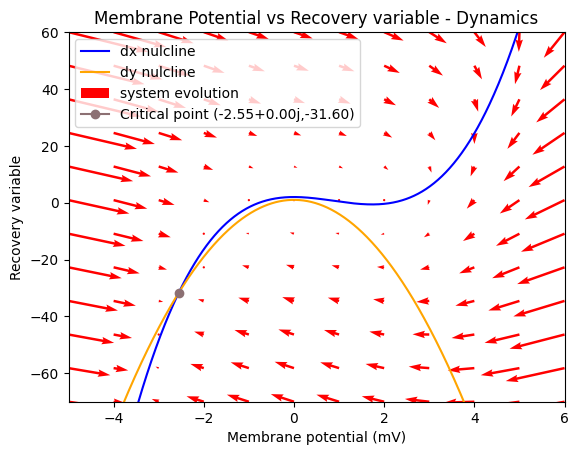

```python
y_factor = 1
x_factor = 3

plt = plot_phase_space(
    plt, x_window, y_window, OX_LABEL, OY_LABEL, TITLE, ox, X, Y, dx_nul_vals,
    X_NUL_COLOR, X_NUL_LABEL, dy_nul_vals, Y_NUL_COLOR, Y_NUL_LABEL,
    dx, x_factor, dy, y_factor, ARROWS_COLOR, ARROWS_LABEL,
    [c_1],\
    [CRIT_POINT_STABLE_MARKER],\
    CRIT_POINT_COLOR, CRIT_POINT_LABEL)

plt.show()
```

#### Critical point stability (c1)

With the previously mentioned jacobian: $$ \begin{gather*} \mathbb{J}_{\dot x, \dot y} = \begin{bmatrix} -3x^2 + 5.2x & 1 \\ -10x & -1 \end{bmatrix} \end{gather*} $$

We must find the eigenvalues on the point: $$ (-2.55, -31.6) $$

As we can see in the cell below, we obtain the following eigenvalues:

```python
eigvals, _ = eig(jacobian(c_1[0], c_1[1]))
eigvals
```

```
array([-33.61960139+0.j,  -0.21722522+0.j])
```

We can see that both are negative real values, so we are talking about a stable node!

#### $z=5$

#### Parameters

```python
common_z_vals = common_z_vals.copy()
common_z_vals['z'] = 5
```

#### Critical points

$$ z = 5 $$$$ \begin{gather*} \text{Nulclines:} \\ y_1 = Ax^3 - Bx^2 - I(\infty) + z = x^3 - 2.6x^2 - 2 + 5 = x^3 - 2.6x^2 + 3 \\ y_2 = C - Dx^2 = 1 - 5x^2 \\ \end{gather*} $$$$ \begin{gather*} &\text{Equation to solve:}& \\ &x^2(x - 2.6 + 5) = 1 + 2 - 5& \\ &x^2(x + 2.4) = -2& \\ \end{gather*} $$

```python
y_1 = lambda x: common_z_vals['a']*x*x*x -\
    common_z_vals['b']*x*x - common_z_vals['i_inf'] + common_z_vals['z']
y_2 = lambda x: common_z_vals['c'] - common_z_vals['d']*x*x

equations = [y_1, y_2]
coefs = [1, 2.4, 0, 2]

x_sols, equations_sols =\
    obtain_critical_points(coefs, equations)

print_equations(common_z_vals['i_inf'], common_z_vals['z'], x_sols, equations_sols)

y_sols = equations_sols[0]

# Critical points
c_1 = (x_sols[0], y_sols[0])
```

```
First equation: y_1 = lambda x: x*x*x - 2.6*x*x + 3
	Solutions:
	 x: [-2.67872384+0.j]
	 y: [-34.87780696]

Second equation: y_2 = lambda x: 1 - 5*x*x
	Solutions:
	 x: [-2.67872384+0.j]
	 y: [-34.87780696]

They are both the same!
```

#### Plot visualization

> **Note**

> Our notation for stable, unstable, ..., points will be:
> - CRIT_POINT_STABLE_MARKER = 'o' -> Stable nodes.
> - CRIT_POINT_SADDLE_MARKER = '$\diamondsuit$' -> Saddle-Points.
> - CRIT_POINT_UNSTABLE_SPIRAL_MARKER = '$\circlearrowright$' -> Unstable Focus.
> - CRIT_POINT_NON_ISOLATED_MARKER = '+' -> Non-isolated equilibrium.

```python
x_window, y_window, ox, X, Y, dx_nul_vals, dy_nul_vals, dx, dy =\
    prepare_phase_space_values(
        [-5, 6], [-70, 60], n_arrows=12j, values=1000, **common_z_vals)
```

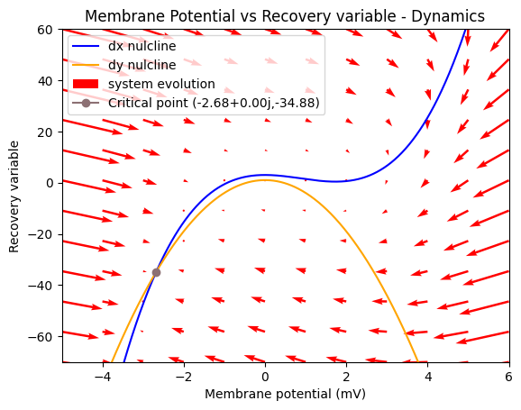

```python
y_factor = 1
x_factor = 3

plt = plot_phase_space(
    plt, x_window, y_window, OX_LABEL, OY_LABEL, TITLE, ox, X, Y, dx_nul_vals,
    X_NUL_COLOR, X_NUL_LABEL, dy_nul_vals, Y_NUL_COLOR, Y_NUL_LABEL,
    dx, x_factor, dy, y_factor, ARROWS_COLOR, ARROWS_LABEL,
    [c_1],\
    [CRIT_POINT_STABLE_MARKER],\
    CRIT_POINT_COLOR, CRIT_POINT_LABEL)

plt.show()
```

#### Critical point stability (c1)

With the previously mentioned jacobian: $$ \begin{gather*} \mathbb{J}_{\dot x, \dot y} = \begin{bmatrix} -3x^2 + 5.2x & 1 \\ -10x & -1 \end{bmatrix} \end{gather*} $$

We must find the eigenvalues on the point: $$ (-2.68, -34.88) $$

As we can see in the cell below, we obtain the following eigenvalues:

```python
eigvals, _ = eig(jacobian(c_1[0], c_1[1]))
eigvals
```

```
array([-36.21668859+0.j,  -0.23935954+0.j])
```

We can see that both are negative real values, so we are talking about a stable node!

## Conclusion and bifurcation diagram

### Membrane potential vs $z$

A bifurcation diagram of the system could be the following:

> **Remember**

> Our notation for stable, unstable, ..., points will be:
> - CRIT_POINT_STABLE_MARKER = 'o' -> Stable nodes.
> - CRIT_POINT_SADDLE_MARKER = '$\diamondsuit$' -> Saddle-Points.
> - CRIT_POINT_UNSTABLE_SPIRAL_MARKER = '$\circlearrowright$' -> Unstable Focus.
> - CRIT_POINT_NON_ISOLATED_MARKER = '+' -> Non-isolated equilibrium.

> **Note**
> - The continue linestyle ('-') refers to stable trajectories.
> - The non-continuous linestyle ('--') refers to unstable trajectories.

$$ \begin{gather*} &Ax^3 - Bx^2 - I(\infty) + z = C - Dx^2& \\ &Ax^3 - Bx^2 + Dx^2 + z = C + I(\infty)& \\ &x^2 (Ax - B + D) + z = C + I(\infty)& \\ &z = C + I(\infty) - x^2 (Ax - B + D)& \\ \end{gather*} $$

```python
# common values
z_fun = lambda x: common_z_vals['c'] + common_z_vals['i_inf'] -\
    x*x*(common_z_vals['a']*x - common_z_vals['b'] + common_z_vals['d'])
values = 1000

linestyles = ['--','-','--','-']

# critical points
critical_points =\
    [(0, 0.95), (1,-1.45), (4,-2.55), (3, 0)]
critical_points_markers =\
    [CRIT_POINT_UNSTABLE_SPIRAL_MARKER,
     CRIT_POINT_SADDLE_MARKER,
     CRIT_POINT_STABLE_MARKER,
     CRIT_POINT_NON_ISOLATED_MARKER]
```

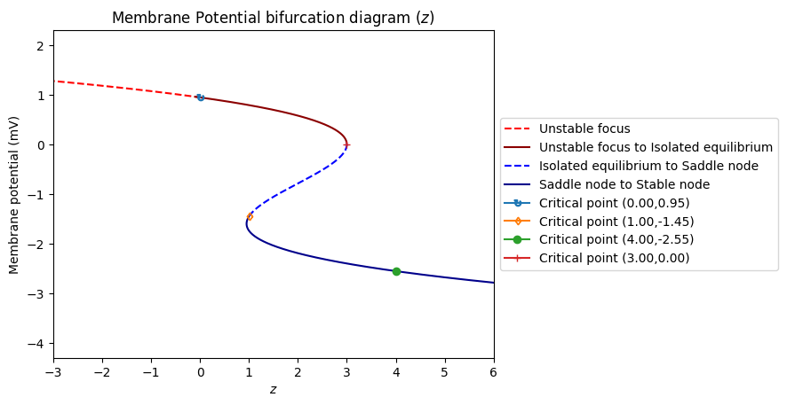

```python
# bifurcations
v_start=[2, 0.96, 0.01, -1.46]
v_stop=[0.94, -0.01, -1.44, -4]
x_curves, y_curves =\
    prepare_bifurcation_plot(z_fun, v_start, v_stop, values)

# bifurcation diagram
plot_bifurcation_diagram(
    plt, x_curves, y_curves, ['r','darkred','blue','darkblue'],
    ['Unstable focus','Unstable focus to Isolated equilibrium',
    'Isolated equilibrium to Saddle node','Saddle node to Stable node',
    'Stable node'], critical_points, critical_points_markers,
    'Critical point', linestyles)

# Plot properties
add_plot_properties(
   plt, x_label="$z$", y_label=OX_LABEL,
   title="Membrane Potential bifurcation diagram $(z)$",
   x_lim =(-3,6))

plt.legend(loc='center left', bbox_to_anchor=(1, 0.5))
```

#### Bifurcation diagram conclusions

This means that in the:

- **Unstable focus** bifurcation: we will enter in a spiral dynamic where we will be stuck in a loop of high and low potential membrane states which will have greater frequencies as the $z$ value decreases, in other words, if we have high values of $V$, then, we will decrease rapidly our $V$ while the Recovery Variable increases to repeat the loop.
- **Unstable focus to Isolated equilibrium (stable)** bifurcation: we can see how all the trajectories tend to go to the equilibrium point $(-2.40, -27.80)$, that means staying on it unless there is any change in $z$ to leave from it. As consequence of this, we will see in the following section how the system stays silent around a $V=-2$ value as it is in a stable equilibrium.
- **Isolated equilibrium to Saddle point (unstable part)** bifurcation: here our system will enter in a mixture of unstable spiral and stable equilibrium depending on the $z$ value. The mechanics are described in the previous two dynamics.
- **Saddle point to Stable equilibriums (stable part)** trajectory: we can observe how our system stays silent as we reach higher values of $z$ starting from $z \in (1, \infty)$ obtaining the same silent mechanic described in the **Unstable focus to Isolated equlibrium (state)**.

### System functioning changing $z$

```python
# parameters
a = A
b = B
c = C
d = D

## pulses
pulse_times = deque()
i_0 = I_0
i_inf = I_INF

# values of time
t = np.arange(T_START, T_END, T_STEP)

# initial state
ini_state = STABLE_STATE

# z values
values = 25
divider = 5
figs_per_row = values//divider

z_start, z_stop = 0.5, 2
z = np.linspace(z_start, z_stop, values)
```

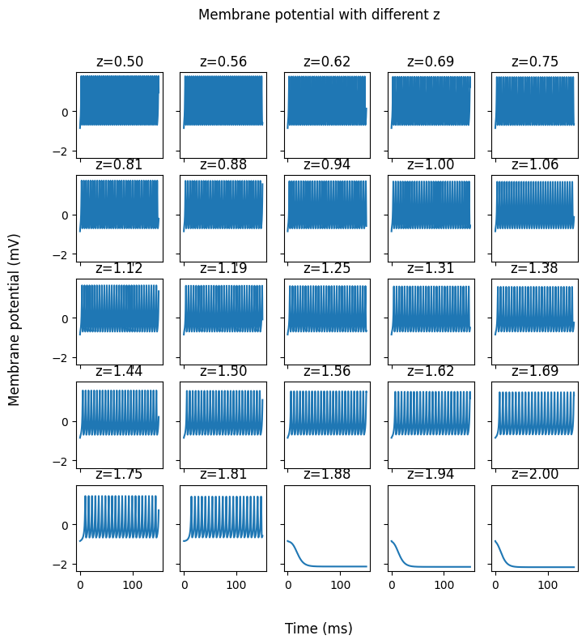

```python
fig, ax = plt.subplots(
    nrows=figs_per_row, ncols=figs_per_row,
    sharex = True, sharey=True, figsize=(8, 8))

# trajectories designation
for idx, z_val in enumerate(z):
    # args
    args = (a, b, c, d, pulse_times, i_0, i_inf, z_val)

    # solving ODE
    state = odeint(hr_dt, ini_state, t, args=args)

    # plot results
    i = idx//(figs_per_row)
    j = idx % (figs_per_row)
    ax[i, j].plot(t, state[:, 0])
    ax[i, j].set_title("z={:.2f}".format(z_val))


fig.suptitle("Membrane potential with different z")
fig.supxlabel(TIME_OX_LABEL)
fig.supylabel(OX_LABEL)
```

#### System functioning conclusions in contrast with the bifurcation diagram

As we have seen in the Bifurcation diagram conclusions, decreasing $z$ augment the spiking frequency, but increasing it diminishes the spikes even making the neuron silent in a stable equilibrium.

Moreover, to explain the 3D system mechanics, it could have sense that negative $z$ values could increase the bursting frequency of spikes while, increasing them (positive $z$ values), could decrease the number of spikes thrown by 3D system bursts. Thus, if we increase to much positive $z$ values we could enter in a stable mechanic where the silences will be more frequent than the bursts appearance.